# Skills Quiz: Model Selection

## Instructions

Use this file to keep a record of your work as you complete the “Skills Quiz: Model Selection” assignment in Canvas.

```r
library(mosaic)
```

## Problem 1

Run this code in R. Notice that the loess curves being fit to the data do not “fit” very well currently. Work through the following parts of this problem to learn how to improve the fit of a loess curve.

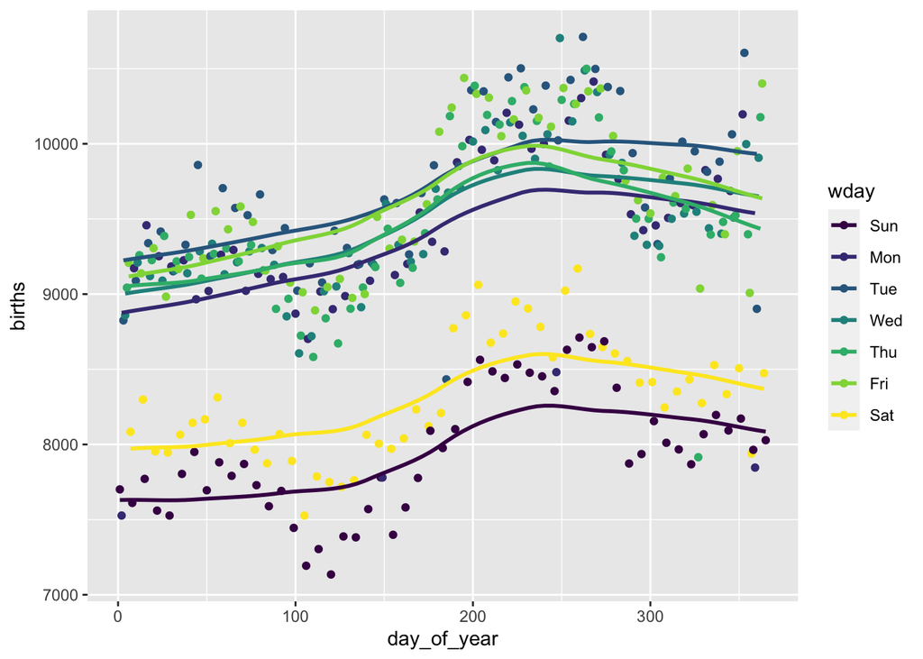

```r
#Ensure library(ggplot2) and library(mosaicData) are loaded
ggplot(Births78, aes(x=day_of_year, y=births, color=wday)) +
  geom_point() +
  geom_smooth(method="loess", span=0.75,
              se=FALSE,
              method.args=list(degree=1))
```

### Part (a)

Copy and paste the code from above, then change the `span` and the `degree` until you come up with a nice fitting set of loess curves. Write a brief comment about how these two choices effect the fit of your loess curves.

- `span` adjusts the percentage of points that are used in each local regression. It should be a number between 0 and 1.
- `degree` changes the type of polynomial that is used in each local regression. A choice of `degree = 1` uses lines and `degree = 2` uses parabolas.

Hint: it may help to add `+ facet_wrap(~wday)` to the end of the above code, which will allow you to see each loess curve in its own little plot.

```r
#Type your code here...
```

### Part (b)

Use your nicely fitting loess curve that you came up with in Part (a) to visually predict the number of births that happened on day 366 of 1978… (i.e., January 1st of 1979, which happened to be a Monday).

How accurate do you think this prediction will be? Why?

## Problem 2

Open the `CO2` data set in R. This data is based around an experiment aimed to understand CO2 `uptake` of plants, which is an important characteristic of a plant’s overall health and longevity. Variables known to be associated with `uptake` were controlled in this experiment at different values to try to model their effect on `uptake`.

- `conc` - the ambient CO2 concentration surrounding the plant. The more CO2 available, the higher the uptake levels should be.
- `Type` - The type of plant. Plants from the warmer climate of Mississippi were compared to plants from a colder climate like Quebec.
- `Treatment` - Plants were either chilled or left un-chilled to see how refrigeration preserved CO2 uptake.

### Part (a)

Create a scatterplot with overlaid loess curves showing how uptake is effected by the (1) ambient CO2 `conc`entration, (2) the `Type` of plant, and (3) the `Treatment` applied to the plant.

Fit loess curves to the data using span=0.6 and degree=2. (You should have four different curves.)

Hint: use a ggplot and `color=interaction(Type, Treatment)`

```r
#Type your code here...
```

### Part (b)

Using one of the four loess curves that were drawn on your plot, predict the `uptake` of CO2 for a plant that is chilled, from Quebec, and is placed in an ambient CO2 concentration of 300 mL/L.

Note: It would be awesome if you could run something like `loess(uptake ~ conc + Treatment + Type, data=CO2)`. Unfortunately, this will not work. Instead, you will need to run something like `loess(uptake ~ conc, data= ...)` where the `...` is an appriopriately reduced version of the `CO2` data. Also, be sure to specify the span and degree in your loess(…) function as instructed in Part (a).

```r
#Type your code here...
```

## Problem 3

Open the `Loblolly` data set in R. Sometimes a lowess curve can be used to help us decide on an appropriate model for data.

### Part (a)

Create a scatterplot of the `height` of a tree on the `age` of the tree. Overlay both a simple linear regression line and a lowess curve, degree 1 on the plot. Does the lowess curve suggest that the line is a good fit or a poor fit?

```r
#Type your code here...
```

### Part (b)

Re-draw the scatterplot, this time overlaying the curve from a quadratic regression model as well as the lowess curve of degree 1. Does this model look better or worse than the simple linear regression line when compared to the lowess curve?

```r
#Type your code here...
```

## Problem 4

Consider the `Utilities` data set. As mentioned in the help file `?Utilities`, this is “data from [monthly] utility bills at a residence.”

Let’s use this data to produce a “best model” for predicting the monthly electricity bill, `elecbill`, for this given residence.

Working through each part of this problem below will guide you through the model selection process.

### Part (a)

A great first step in model selection is to identify explanatory variables that can be used to successfully predict a response variable.

Create a pairs plot of the `Utilities` data set. Then, identify the row of the pairs plot that corresponds to `elecbill` being the y-variable in each plot contained in that row. This is the main row you want to look at as you decide which variable is most useful in explaining y, the `elecbill`.

```r
# hint: pairs(dataSetName, panel = panel.smooth, pch=16, cex=0.7, col=rgb(.2,.2,.2,.5))
```

### Part (b)

Fit a simple linear regression model on the most “useful” variable for predicting `elecbill`.

State the p-value for the $\beta_1$ term. State the $R^2$ value of the regression. Show the residuals vs fitted values plot for the regression. What do each of these show?

```r
#Type your code here...
```

### Part (c)

Create a new pairs plot that includes the residuals and fitted values from the previous regression.

Hint: `cbind(R = lm1$res, Fit = lm1$fit, Utilities)`

There are a lot of interesting patterns in the pairs plot at this point. Identify all of the plots that seem like they might explain something useful about the residuals from the regression in Part (b).

Notice how `month` is strongly related to several variables in a quadratic way. Identify the scatterplots where month, acting as the x-variable, is a strong predictor of those variables.

Thus, while many variables could give some insight on the residuals, month seems to explain most of them, so that would suggest using month as a variable that could explain elecbill. Also, month would be the best choice to actually use over any of the other related variables, because it would be the easiest variable to “measure” in real life. However, there is one other variable that does not relate to `month` that also seems to shed some insight on the residuals from the regression from Part (b).

Which variable is this? (It shows a low correlation, but positive linear relationship and is not related to month at all according to the pairs plots.)

```r
#Type your code here...
```

### Part (d)

Perform a second regression that adds both of these newly identified variables to the regression performed in Part (b). This should now be a regression of elecbill on three different explanatory variables.

Report the p-values of each of the two new variables, as well as the $R^2$ value of the regression, and create a residuals vs fitted values plot for the regression.

What do each of these values show?

```r
#Type your code here...
```

### Part (e)

Add to the regression model of Part (d) a quadratic `month` term. Note how the p-values of all terms have now changed. State the adjusted $R^2$ value of the regression. Create a residuals vs fitted values plot of the regression.

What does all of this show?

```r
#Type your code here...
```

### Part (f)

Let’s check one more time if any other variables should be added to the model before we try a transformation.

Create another pairs plot that uses the residuals and fitted values from the regression in Part (d). What do you see?

```r
#Type your code here...
```

### Part (g)

Perform a regression that includes temp and I(temp^2) into the regression from Part (e).

What happens to the p-values for month and I(month^2)?

What is the adjusted R-squared of this model?

### Part (h)

Drop month and I(month^2) from the model in Part (g) but leave all other terms in the model.

What is the adjusted R-squared of this model?

What does the residuals vs fitted values plot show?

```r
#Type your code here...
```

### Part (i)

Though we could check another pairs plot at this point (it actually doesn’t show anything useful), let’s try a y-transformation instead, just for fun. Run boxCox(…) on your lm from Part (h). Which value of $\lambda$ is suggested?

```r
#Type your code here...
```

### Part (j)

State the equation for the final regression model for predicting elecbill. What is the adjusted R-squared of this final model?

**Concluding Comments**

elecbill ~ year + I(month^2), data = Utilities